# Building a Meta-database of Marine Research in Mexico

The Meta-database of Marine Research in Mexico project aims to create a meta-database of all marine research data developed in Mexico. A meta-database is a documentation of the sources of information instead of a database of the actual data. Since October of 2016 we have collected more than 100 k records containing information from more than 300 k data points, from more than 60 on-line repositories. You can read the details on the project’s webpage as well as some of our preeliminary results.

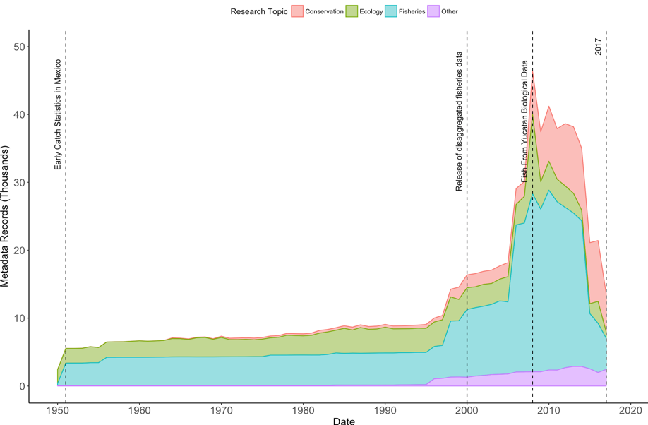

[Visit Project’s Webpage [Visitar la Página del Proyecto](https://jepa.shinyapps.io/marmetadatamexesp/)](https://jepa.shinyapps.io/marmetadatamexeng/)

## Working Papers

- **Palacios-Abrantes J.**, & Cisneros-Montemayor A. (2018). Tendencias de la investigación pesquera en México: necesidades y oportunidades para la adaptación al cambio climático. In *Pescadores en México retos y oportunidades ante el cambio climático. Ciudad de México*. *In press*
- **Palacios-Abrantes J.**, Cisneros-Montemayor A.M., Cisneros-Mata M.A., Rodríguez L.F., Arreguín-Sánchez, F. Cheung W.L. (NA). A metadata approach to evaluate the state of ocean knowledge: Strengths, limitations, and application to Mexico.

## Related Work

- [MarXiv Ambassadors](https://www.marxivinfo.org/ambassadors). MarXiv Ambassadors serve as preprint-sharing experts for the local institutions, helping their fellow researchers determine which documents can (and cannot) be legally shared in MarXiv.

## News

- [Oceans Deeply; MarXiv](https://www.newsdeeply.com/oceans/articles/2018/01/18/tear-down-that-paywall-the-movement-to-make-ocean-research-free-for-all)
- [CONACYT Prensa; MetaMares (Spanish)](http://conacytprensa.mx/index.php/ciencia/mundo-vivo/13008-crean-base-de-metadatos-de-investigacion-marina-en-mexico)
- [Blog de EDF de México; MetaMares (Spanish)](http://mexico.edf.org/blog/2017/06/13/colabora-en-la-construccion-de-un-catalogo-sobre-informacion-marina-en-mexico)

[Back to Research](https://www.julianopalacios.com/Research.html) Next Project

**Contact**

Juliano Palacios Abrantes | j.palacios@oceans.ubc.ca • [Google Schoolar](https://scholar.google.ca/citations?user=EZpBcjcAAAAJ&hl=en)